# Interpolate weather station data

## Interpolation

There are a number of options for spatial interpolation from point to raster. These include nearest neighbor interpolation, inverse distance weighted (IDW), and ordinary kriging.

Will make one raster for each variable of interest, per day, and then apply to grid/hour. Here use kriging from the package [`gstat`](https://cran.r-project.org/web/packages/gstat/vignettes/gstat.pdf). Models are all based on spatial variance of the target variable.

The steps in brief are as follows:

- Create an empty raster grid for the state; we will interpolate over this grid, then assign values from the raster to each grid cell. Increase `n` for smaller raster cells (more time-intensive)
- For each target variable, each data, calculate the semi-variance of the data. This shows how much spatial autocorrelation there is between the sample points ([ArcGIS reference](https://pro.arcgis.com/en/pro-app/help/analysis/geostatistical-analyst/understanding-a-semivariogram-the-range-sill-and-nugget.htm))
- Fit a modeled variogram to the data ([ArcGIS reference](https://pro.arcgis.com/en/pro-app/help/analysis/geostatistical-analyst/fitting-a-model-to-the-empirical-semivariogram.htm))
- Krige the data to the raster surface ([ArcGIS reference](https://pro.arcgis.com/en/pro-app/help/analysis/geostatistical-analyst/understanding-ordinary-kriging.htm))
- Extract values from the raster layer to the grid spatial polygon layer and produce a data frame of the interpolated values for the target variable, for the day

The last step is the most computationally-intensive one. If the end product you need is just the raster layer, these steps are very fast. In order to speed things along, this code shows how to implement the steps in parallel to take full advantage of your machine’s cores.

```r
grd <- as.data.frame(spsample(grid_shp, 'regular', n = 5000))
names(grd) <- c("X", "Y")
coordinates(grd) <- c("X", "Y")
gridded(grd) <- TRUE # for SpatialPixel
fullgrid(grd) <- TRUE # for SpatialGrid
proj4string(grd) <- proj4string(grid_shp)

StartTime <- Sys.time()

writeLines(c(""), paste0("Prep_Weather_log.txt"))

# This step sets up the parallel process. In combination with foreach() below, it provides a simple way to take advantage of multiple cores.
cl <- makeCluster(parallel::detectCores())
registerDoParallel(cl)

# Can limit to a few select months with this code, or manually set 'do.months' to a value like '2017-06'.
do.months = c(paste('2017', formatC(4:12, width = 2, flag = 0), sep = '-'),
              paste('2018', formatC(1:3, width = 2, flag = 0), sep = '-'))

# Start with one example month, comment out this line to run over whole data set (time intensive!)
do.months = c('2017-06')

# Choose one day to save an example raster image for each target variable
ex.day = '2017-06-01'

all_wx_days = unique(wx$DATE)
all_wx_ym = format(all_wx_days, "%Y-%m")
use_wx_days = all_wx_days[all_wx_ym %in% do.months]

# use_wx_days = use_wx_days[1:4] # for even smaller test of four days

# Start loop ----

wx.grd.day <- foreach(day = use_wx_days,
                      .packages = c('raster','gstat','dplyr','rgdal'),
                      .combine = rbind) %dopar% {
    # day = use_wx_days[1]

  dayStartTime <- Sys.time()

  wx.day = wx.proj[wx.proj$DATE == day,]

  ### Precipitation
  f.p <- as.formula(PRCP ~ 1)

  vg_prcp <- gstat::variogram(PRCP ~ 1, locations = wx.day[!is.na(wx.day$PRCP),])
  dat.fit <- fit.variogram(vg_prcp, fit.ranges = F, fit.sills = F,
                             vgm(model = "Sph"))
  # plot(vg_prcp, dat.fit) # Plot the semi variogram.
  dat.krg.prcp <- krige(f.p, wx.day[!is.na(wx.day$PRCP),], grd, dat.fit)

  # Rasterize
  prcp_r <- raster::raster(dat.krg.prcp)
  prcp_r <- mask(prcp_r, grid_shp)

  if(day == ex.day) { save(prcp_r, file = file.path(usedir, 'example_prcp_raster.RData')) }

  ### Daily high temperatures
  f.tmax <- as.formula(TMAX ~ 1)
  vg_tmax <- variogram(TMAX ~ 1, wx.day[!is.na(wx.day$TMAX),])
  dat.fit <- fit.variogram(vg_tmax, fit.ranges = F, fit.sills = F,
                           vgm(model = "Sph"))
  dat.krg.tmax <- krige(f.tmax, wx.day[!is.na(wx.day$TMAX),], grd, dat.fit)
  tmax_r <- raster::raster(dat.krg.tmax)
  tmax_r <- mask(tmax_r, grid_shp)

  if(day == ex.day) { save(tmax_r, file = file.path(usedir, 'example_tmax_raster.RData')) }

  # Apply to grid cells in year-day ----
  # This is the most time-intensive step in the process.
  # Need to extract values from the raster layers to the polygons
  prcp_extr <- raster::extract(x = prcp_r,   # Raster object
                               y = grid_shp, # SpatialPolygons
                               fun = mean,
                               df = TRUE)

  names(prcp_extr)[2] = "PRCP"
  prcp_extr$ID = grid_shp$GRID_ID

  daily_result <- data.frame(day, prcp_extr)

  tmax_extr <- raster::extract(x = tmax_r,   # Raster object
                               y = grid_shp, # SpatialPolygons
                               fun = mean,
                               df = TRUE)
  names(tmax_extr)[2] = "TMAX"
  tmax_extr$ID = grid_shp$GRID_ID

  daily_result <- full_join(daily_result, tmax_extr)

  dayEndTime <- Sys.time() - dayStartTime
  cat(as.character(day), 'completed', round(dayEndTime, 2), attr(dayEndTime, 'units'), '\n',
      file = paste0("Prep_Weather_log.txt"), append = T)
    daily_result
  } # end parallel loop

EndTime <- Sys.time()-StartTime
cat('Entire process completed in', round(EndTime, 2), attr(EndTime, 'units'), '\n',
      file = paste0("Prep_Weather_log.txt"), append = T)

# Save the ouput
save(list = c('wx.grd.day'),
       file = file.path(usedir, 'Interpolated_Gridded_Daily_Data.RData'))
```

## Plot raster interpolation

We can view some of intermediate raster surfaces which were produced by the interpolation. Here looking at the TMAX and PRCP surfaces for one example day in June 2017:

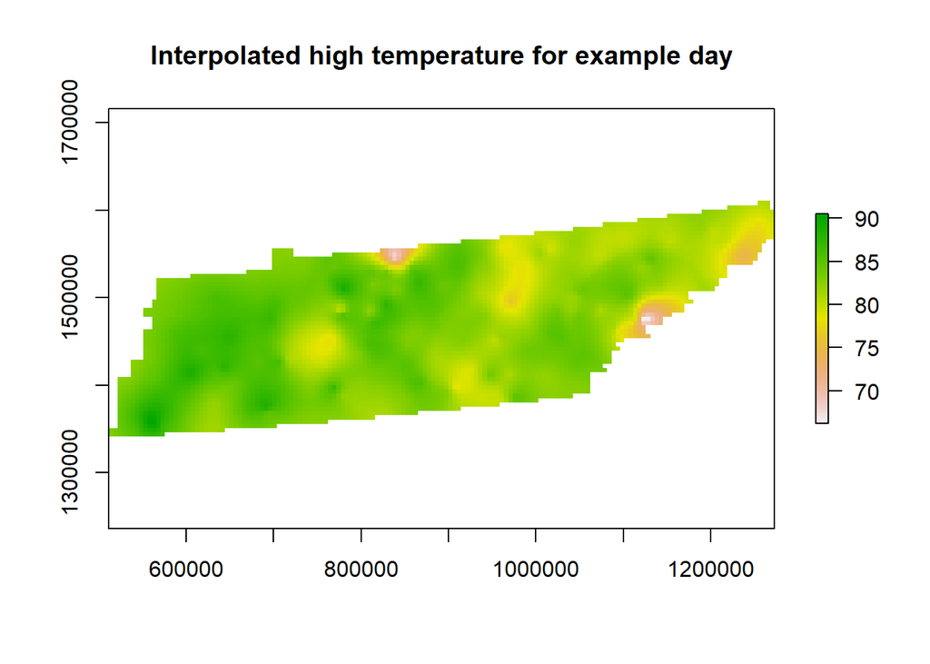

```r
load('example_prcp_raster.RData')
load('example_tmax_raster.RData')

plot(tmax_r, main = 'Interpolated high temperature for example day')
```

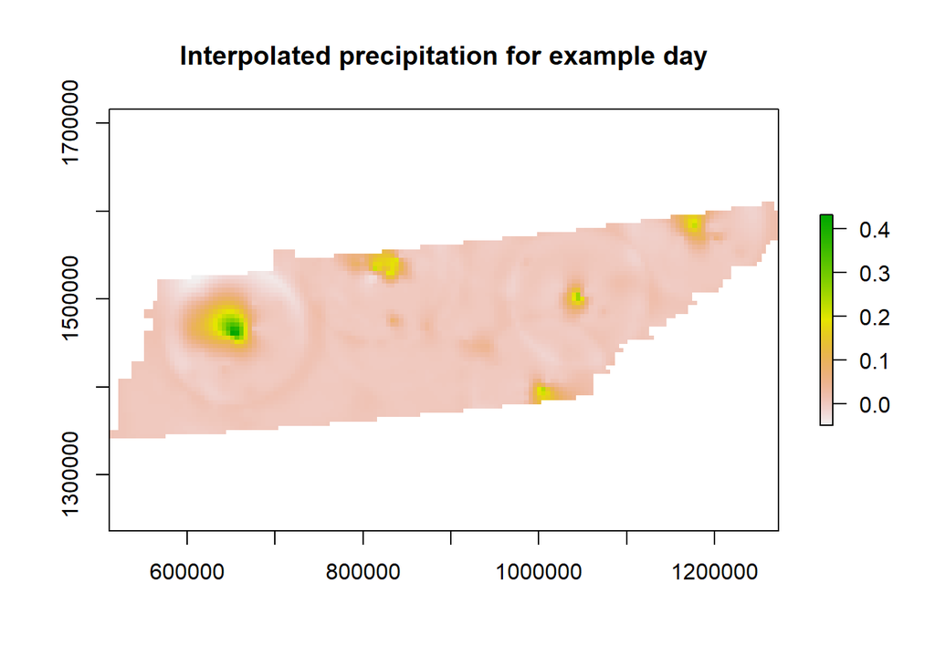

```r
plot(prcp_r, main = 'Interpolated precipitation for example day')
```